# AssociationRules-SEA-building-energy-bechmarking

Christopher Lacrampe

December 04, 2018

# 1. Loading, cleaning, and preparing the data/libraries

### 1.1 Loading libraries and datasets

```r
library(gmodels) # useful library for CrossTabs/confusion matrices
library(arules) # has the functions to create rule associations
library(tidyverse) # has useful libraries for cleaning and filtering data
energyDat2016 = read.csv("sea-building-energy-benchmarking/2015-building-energy-benchmarking.csv", stringsAsFactors = FALSE)
```

### 1.2 Cleaning the data

#### 1.2.1 Removing outliers

Our dataset has come prepared with an **Outlier** feature where the data controller has flagged outliers as “High” and “Low”, we will remove those outliers

```r
energyDat2016 = tbl_df(filter(energyDat2016, Outlier == ""))
energyDat2016 = as.data.frame(energyDat2016)
```

```r
StarScore = ifelse(energyDat2016$ENERGYSTARScore >= 75, "Good", "Bad")
energyDat2016$StarScore = StarScore
energyDat2016$StarScore = as.factor(energyDat2016$StarScore)
```

#### 1.2.3 Create a dataframe utilizing the variables we want to include in our model (this strips redundant variables that are identical to the others just measured in different units)

```r
modelDat = select(energyDat2016, StarScore, YearBuilt, PrimaryPropertyType, BuildingType, Neighborhood, NumberofFloors)
# remove NA values
modelDat = na.omit(modelDat)
```

#### 1.2.4 Coercing all variable in subset to factors to mimic transactional data frames

```r
modelDat$YearBuilt = as.factor(modelDat$YearBuilt)
modelDat$NumberofFloors = as.factor(modelDat$NumberofFloors)
modelDat$PrimaryPropertyType = as.factor(modelDat$PrimaryPropertyType)
modelDat$BuildingType = as.factor(modelDat$BuildingType)
modelDat$Neighborhood = as.factor(modelDat$Neighborhood)
transactionDat = as(modelDat, "transactions")
```

# 2. Exploring transactionDat object

### 2.1 Utilizing indexing to access elements of the object

#### 2.1.1 How to get the basic information about the transaction matrix? Explain the first block of output.

```r
summary(transactionDat)
```

```
## transactions as itemMatrix in sparse format with
##  2488 rows (elements/itemsets/transactions) and
##  205 columns (items) and a density of 0.02926829
##
## most frequent items:
##                           StarScore=Good
##                                     1277
##                            StarScore=Bad
##                                     1211
##              BuildingType=NonResidential
##                                      985
##        BuildingType=Multifamily LR (1-4)
##                                      865
## PrimaryPropertyType=Low-Rise Multifamily
##                                      845
##                                  (Other)
##                                     9745
##
## element (itemset/transaction) length distribution:
## sizes
##    6
## 2488
##
##    Min. 1st Qu.  Median    Mean 3rd Qu.    Max.
##       6       6       6       6       6       6
##
## includes extended item information - examples:
##           labels variables levels
## 1  StarScore=Bad StarScore    Bad
## 2 StarScore=Good StarScore   Good
## 3 YearBuilt=1900 YearBuilt   1900
##
## includes extended transaction information - examples:
##   transactionID
## 1             1
## 2             2
## 3             3
```

The first block of the output contains general information: 2488 transactions with 205 distinct items.

#### 2.1.3 What is the percentage of the good item appearing in transactions? How about the bad rating for star score?

```r
1277/2488
```

```
## [1] 0.5132637
```

```r
1211/2488
```

```
## [1] 0.4867363
```

51.32% of the transactions have ‘good’ in them while 48.67% of the transactions have ‘bad’ in them.

#### 2.1.4 How many items are in 50% of transactions?

```r
itemFrequency(transactionDat[])
```

```
##                                   StarScore=Bad
##                                    0.4867363344
##                                  StarScore=Good
##                                    0.5132636656
##                                  YearBuilt=1900
##                                    0.0116559486
##                                  YearBuilt=1901
##                                    0.0016077170
##                                  YearBuilt=1902
##                                    0.0024115756
##                                  YearBuilt=1903
##                                    0.0008038585
##                                  YearBuilt=1904
##                                    0.0048231511
##                                  YearBuilt=1905
##                                    0.0032154341
##                                  YearBuilt=1906
##                                    0.0052250804
##                                  YearBuilt=1907
##                                    0.0100482315
##                                  YearBuilt=1908
##                                    0.0080385852
##                                  YearBuilt=1909
##                                    0.0088424437
##                                  YearBuilt=1910
##                                    0.0168810289
##                                  YearBuilt=1911
##                                    0.0032154341
##                                  YearBuilt=1912
##                                    0.0036173633
##                                  YearBuilt=1913
##                                    0.0024115756
##                                  YearBuilt=1914
##                                    0.0072347267
##                                  YearBuilt=1915
##                                    0.0016077170
##                                  YearBuilt=1916
##                                    0.0068327974
##                                  YearBuilt=1917
##                                    0.0028135048
```

[output cut: 355 more lines]

```
##                                    0.0004019293
##                               NumberofFloors=47
##                                    0.0004019293
##                               NumberofFloors=49
##                                    0.0004019293
##                               NumberofFloors=55
##                                    0.0004019293
##                               NumberofFloors=56
##                                    0.0004019293
##                               NumberofFloors=63
##                                    0.0004019293
##                               NumberofFloors=76
##                                    0.0004019293
##                               NumberofFloors=99
##                                    0.0004019293
```

#### 2.1.5 How to inspect the 4th, 5th, and 6th transactions? How to see the proportion of transactions that contain the 4th 5th and 6th items? How to explain those later results?

```r
inspect(transactionDat[4:6])
```

```
##     items                         transactionID
## [1] {StarScore=Bad,
##      YearBuilt=1980,
##      PrimaryPropertyType=Hotel,
##      BuildingType=NonResidential,
##      Neighborhood=DOWNTOWN,
##      NumberofFloors=18}                       4
## [2] {StarScore=Bad,
##      YearBuilt=1926,
##      PrimaryPropertyType=Hotel,
##      BuildingType=NonResidential,
##      Neighborhood=DOWNTOWN,
##      NumberofFloors=11}                       6
## [3] {StarScore=Bad,
##      YearBuilt=1904,
##      PrimaryPropertyType=Hotel,
##      BuildingType=NonResidential,
##      Neighborhood=DOWNTOWN,
##      NumberofFloors=15}                       8
```

```r
itemFrequency(transactionDat[,4:6])
```

```
## YearBuilt=1901 YearBuilt=1902 YearBuilt=1903
##   0.0016077170   0.0024115756   0.0008038585
```

### 2.2 Visuualizing the transaction data = plotting the sparse matrix

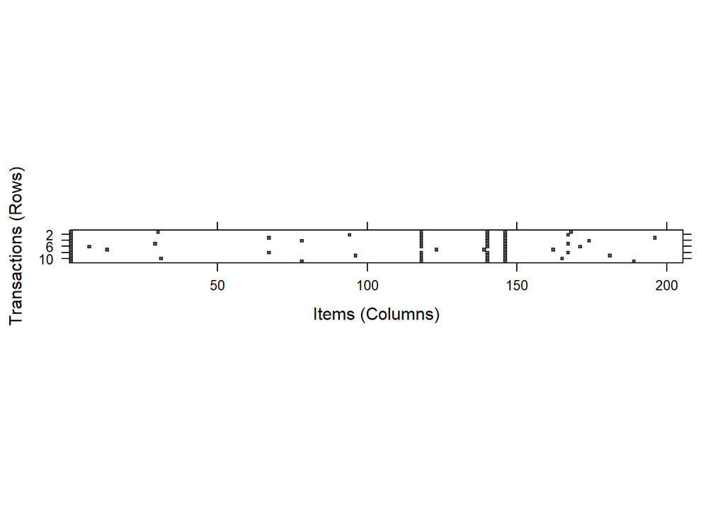

```r
image(transactionDat[1:11])
```

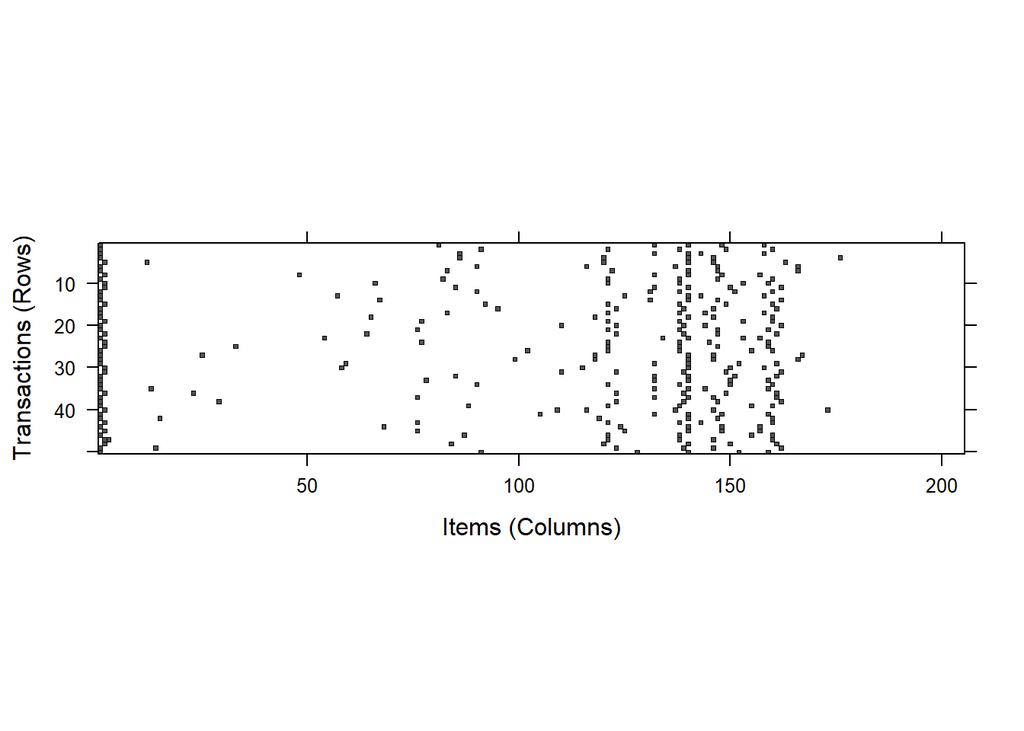

```r
image(sample(transactionDat, 50))
```

# 3. Training association rules on the data

### 3.1 How to create sets of rules with the apriori() function? Explain the result and why it is not surprising for our data?

```r
apriori(transactionDat)
```

```
## Apriori
##
## Parameter specification:
##  confidence minval smax arem  aval originalSupport maxtime support minlen
##         0.8    0.1    1 none FALSE            TRUE       5     0.1      1
##  maxlen target   ext
##      10  rules FALSE
##
## Algorithmic control:
##  filter tree heap memopt load sort verbose
##     0.1 TRUE TRUE  FALSE TRUE    2    TRUE
##
## Absolute minimum support count: 248
##
## set item appearances ...[0 item(s)] done [0.00s].
## set transactions ...[205 item(s), 2488 transaction(s)] done [0.00s].
## sorting and recoding items ... [14 item(s)] done [0.00s].
## creating transaction tree ... done [0.00s].
## checking subsets of size 1 2 3 done [0.00s].
## writing ... [16 rule(s)] done [0.00s].
## creating S4 object  ... done [0.00s].
```

```
## set of 16 rules
```

### 3.2 Adjusting support and confidence thresholds to 0.05 and 0.5 respectively. Also setting minlen = 2 to remove rules that contain fewer than two items

```r
energyrules = apriori(transactionDat, parameter = list(support = 0.05, confidence = 0.5, minlen = 2))
```

```
## Apriori
##
## Parameter specification:
##  confidence minval smax arem  aval originalSupport maxtime support minlen
##         0.5    0.1    1 none FALSE            TRUE       5    0.05      2
##  maxlen target   ext
##      10  rules FALSE
##
## Algorithmic control:
##  filter tree heap memopt load sort verbose
##     0.1 TRUE TRUE  FALSE TRUE    2    TRUE
##
## Absolute minimum support count: 124
##
## set item appearances ...[0 item(s)] done [0.00s].
## set transactions ...[205 item(s), 2488 transaction(s)] done [0.00s].
## sorting and recoding items ... [25 item(s)] done [0.00s].
## creating transaction tree ... done [0.00s].
## checking subsets of size 1 2 3 4 done [0.00s].
## writing ... [97 rule(s)] done [0.00s].
## creating S4 object  ... done [0.00s].
```

### 3.3 How to obtain a high-level overview of the association rules? Explain each part of the output

```r
energyrules
```

```
## set of 97 rules
```

```r
summary(energyrules)
```

```
## set of 97 rules
##
## rule length distribution (lhs + rhs):sizes
##  2  3  4
## 37 48 12
##
##    Min. 1st Qu.  Median    Mean 3rd Qu.    Max.
##   2.000   2.000   3.000   2.742   3.000   4.000
##
## summary of quality measures:
##     support          confidence          lift            count
##  Min.   :0.05024   Min.   :0.5038   Min.   :0.9816   Min.   :125.0
##  1st Qu.:0.06350   1st Qu.:0.5500   1st Qu.:1.3670   1st Qu.:158.0
##  Median :0.08722   Median :0.7071   Median :2.3628   Median :217.0
##  Mean   :0.10346   Mean   :0.7666   Mean   :2.6064   Mean   :257.4
##  3rd Qu.:0.11696   3rd Qu.:0.9793   3rd Qu.:2.8763   3rd Qu.:291.0
##  Max.   :0.33963   Max.   :1.0000   Max.   :5.8256   Max.   :845.0
##
## mining info:
##            data ntransactions support confidence
##  transactionDat          2488    0.05        0.5
```

Our ruleset contains 97 rules. In the first chunk of the output, we can see the count of rules by number of items (i.e. 37 rules of 2 items, 48 rules of 3 items, and 12 rules of 4 items).

The next section of output includes summary statistics for our rules, where we can see most of the rules expanding beyond our minimum support and confidence thresholds. This indicates that we have good thresholds because if these measures were closer to the threshold then we might have set our thresholds too high. The third column, lift, has values greater than 1 for most rules (1st quartile and onward) which is good. If lift == 1 we would be better off with random chance.

# 4. Evaluating model performance:

### 4.1 How to look at the first three rules in the energyrules object? Explain and discuss the results:

```r
inspect(energyrules[1:3])
```

```
##     lhs                                                 rhs                                           support confidence     lift count
## [1] {PrimaryPropertyType=Non-Refrigerated Warehouse} => {BuildingType=NonResidential}              0.05707395  0.9793103 2.473629   142
## [2] {PrimaryPropertyType=Large Office}               => {BuildingType=NonResidential}              0.06069132  0.9869281 2.492870   151
## [3] {NumberofFloors=6}                               => {PrimaryPropertyType=Mid-Rise Multifamily} 0.06350482  0.7314815 4.222566   158
```

However, we want to also inspect the rules using three criteria: whether the rule is *Actionable*, *Trivial*, or *Inexplicable*. From our output the PrimaryPropertyType=Non-Refrigerated Warehouse->BuildingType=NonResidential rule could be considered trivial as it intuitively makes sense and seems uninteresting. The same holds true for the second rule. Finally, the NumerofFloors=6->PrimaryPropertyType=Mid-Rise Multifamily could be classified as Actionable or Trivial depending upon outlook.

# 4. Improving model performance

### 4.1 Sorting the set of association rules

We can use sort() and select a parameter to inspect and evaluate rules learned by the model

```r
inspect(sort(energyrules, by = 'support')[95:97])
```

```
##     lhs                              rhs                              support confidence      lift count
## [1] {NumberofFloors=5}            => {StarScore=Good}              0.05345659  0.5859031 1.1415246   133
## [2] {BuildingType=NonResidential,
##      Neighborhood=DOWNTOWN}       => {StarScore=Good}              0.05024116  0.5122951 0.9981129   125
## [3] {StarScore=Good,
##      Neighborhood=DOWNTOWN}       => {BuildingType=NonResidential} 0.05024116  0.6281407 1.5866133   125
```

#### 4.1.2 What are the best 6 rules according to the lift statistic? Explain the results.

```r
inspect(sort(energyrules, by = 'lift')[1:6])
```

```
##     lhs                                           rhs                                           support confidence     lift count
## [1] {BuildingType=NonResidential,
##      Neighborhood=GREATER DUWAMISH}            => {NumberofFloors=1}                         0.05586817  0.6813725 5.825618   139
## [2] {BuildingType=Multifamily MR (5-9),
##      NumberofFloors=6}                         => {PrimaryPropertyType=Mid-Rise Multifamily} 0.06350482  0.9875000 5.700464   158
## [3] {BuildingType=Multifamily MR (5-9),
##      NumberofFloors=5}                         => {PrimaryPropertyType=Mid-Rise Multifamily} 0.06109325  0.9870130 5.697653   152
## [4] {StarScore=Bad,
##      BuildingType=Multifamily MR (5-9)}        => {PrimaryPropertyType=Mid-Rise Multifamily} 0.05908360  0.9800000 5.657169   147
## [5] {BuildingType=Multifamily MR (5-9)}        => {PrimaryPropertyType=Mid-Rise Multifamily} 0.17323151  0.9773243 5.641723   431
## [6] {PrimaryPropertyType=Mid-Rise Multifamily} => {BuildingType=Multifamily MR (5-9)}        0.17323151  1.0000000 5.641723   431
```

For each of the top 6 rules by lift, each rule has a lift > 5.6. The rule with the highest lift is: BuildingType=NonResidential,Neighborhood=GREATER DUWAMISH-> NumberofFloors=1. This rule makes sense, as the greater duwamish area overlaps with SODO, which is primarily an industrial district. So, most buildings in that region are nonResidential and many of them are warehouses or factories with only 1 floor. Several of the other rules in this category seem just as trivial.

### 4.2 Taking subsets of association rules

#### 4.2.1 How to do that? Inspect those results and discuss the association rules you found.

```r
goodrules = subset(energyrules, items %in% "StarScore=Good")
inspect(goodrules)
```

```
##      lhs                                           rhs                                           support confidence      lift count
## [1]  {NumberofFloors=6}                         => {StarScore=Good}                           0.05747588  0.6620370 1.2898576   143
## [2]  {NumberofFloors=5}                         => {StarScore=Good}                           0.05345659  0.5859031 1.1415246   133
## [3]  {Neighborhood=MAGNOLIA / QUEEN ANNE}       => {StarScore=Good}                           0.08078778  0.6242236 1.2161851   201
## [4]  {Neighborhood=EAST}                        => {StarScore=Good}                           0.07274920  0.5041783 0.9822988   181
## [5]  {Neighborhood=DOWNTOWN}                    => {StarScore=Good}                           0.07998392  0.5037975 0.9815569   199
## [6]  {PrimaryPropertyType=Mid-Rise Multifamily} => {StarScore=Good}                           0.11414791  0.6589327 1.2838094   284
## [7]  {BuildingType=Multifamily MR (5-9)}        => {StarScore=Good}                           0.11696141  0.6598639 1.2856237   291
## [8]  {NumberofFloors=3}                         => {StarScore=Good}                           0.11334405  0.5351044 1.0425526   282
## [9]  {NumberofFloors=4}                         => {StarScore=Good}                           0.11736334  0.5149912 1.0033657   292
## [10] {PrimaryPropertyType=Low-Rise Multifamily} => {StarScore=Good}                           0.17765273  0.5230769 1.0191193   442
## [11] {BuildingType=Multifamily LR (1-4)}        => {StarScore=Good}                           0.18247588  0.5248555 1.0225845   454
## [12] {BuildingType=NonResidential,
##       Neighborhood=DOWNTOWN}                    => {StarScore=Good}                           0.05024116  0.5122951 0.9981129   125
## [13] {StarScore=Good,
##       Neighborhood=DOWNTOWN}                    => {BuildingType=NonResidential}              0.05024116  0.6281407 1.5866133   125
## [14] {PrimaryPropertyType=Mid-Rise Multifamily,
##       BuildingType=Multifamily MR (5-9)}        => {StarScore=Good}                           0.11414791  0.6589327 1.2838094   284
## [15] {StarScore=Good,
##       PrimaryPropertyType=Mid-Rise Multifamily} => {BuildingType=Multifamily MR (5-9)}        0.11414791  1.0000000 5.6417234   284
## [16] {StarScore=Good,
##       BuildingType=Multifamily MR (5-9)}        => {PrimaryPropertyType=Mid-Rise Multifamily} 0.11414791  0.9759450 5.6337615   284
## [17] {PrimaryPropertyType=Low-Rise Multifamily,
##       NumberofFloors=3}                         => {StarScore=Good}                           0.07717042  0.5454545 1.0627180   192
## [18] {StarScore=Good,
##       NumberofFloors=3}                         => {PrimaryPropertyType=Low-Rise Multifamily} 0.07717042  0.6808511 2.0046834   192
## [19] {BuildingType=Multifamily LR (1-4),
##       NumberofFloors=3}                         => {StarScore=Good}                           0.07958199  0.5500000 1.0715740   198
## [20] {StarScore=Good,
##       NumberofFloors=3}                         => {BuildingType=Multifamily LR (1-4)}        0.07958199  0.7021277 2.0195302   198
## [21] {PrimaryPropertyType=Low-Rise Multifamily,
##       NumberofFloors=4}                         => {StarScore=Good}                           0.09445338  0.5199115 1.0129521   235
## [22] {StarScore=Good,
##       NumberofFloors=4}                         => {PrimaryPropertyType=Low-Rise Multifamily} 0.09445338  0.8047945 2.3696198   235
## [23] {StarScore=Good,
##       PrimaryPropertyType=Low-Rise Multifamily} => {NumberofFloors=4}                         0.09445338  0.5316742 2.3329902   235
## [24] {BuildingType=Multifamily LR (1-4),
##       NumberofFloors=4}                         => {StarScore=Good}                           0.09646302  0.5183585 1.0099264   240
## [25] {StarScore=Good,
##       NumberofFloors=4}                         => {BuildingType=Multifamily LR (1-4)}        0.09646302  0.8219178 2.3640827   240
```

[output cut: 14 more lines]

```
## [32] {StarScore=Good,
##       BuildingType=Multifamily LR (1-4),
##       NumberofFloors=3}                         => {PrimaryPropertyType=Low-Rise Multifamily} 0.07717042  0.9696970 2.8551551   192
## [33] {PrimaryPropertyType=Low-Rise Multifamily,
##       BuildingType=Multifamily LR (1-4),
##       NumberofFloors=4}                         => {StarScore=Good}                           0.09445338  0.5199115 1.0129521   235
## [34] {StarScore=Good,
##       PrimaryPropertyType=Low-Rise Multifamily,
##       NumberofFloors=4}                         => {BuildingType=Multifamily LR (1-4)}        0.09445338  1.0000000 2.8763006   235
## [35] {StarScore=Good,
##       BuildingType=Multifamily LR (1-4),
##       NumberofFloors=4}                         => {PrimaryPropertyType=Low-Rise Multifamily} 0.09445338  0.9791667 2.8830375   235
## [36] {StarScore=Good,
##       PrimaryPropertyType=Low-Rise Multifamily,
##       BuildingType=Multifamily LR (1-4)}        => {NumberofFloors=4}                         0.09445338  0.5316742 2.3329902   235
```

#### 4.2.2 How to find the rules that have StarScore=Good and PrimaryPropertyType=Mid-Rise Multifamily together with a confidence greater than 30 percent?

```r
goodrules30 = subset(energyrules, items %ain% c("StarScore=Good", "PrimaryPropertyType=Mid-Rise Multifamily"), confidence > 0.30)
inspect(goodrules30)
```

```
##     lhs                                           rhs                                          support confidence     lift count
## [1] {PrimaryPropertyType=Mid-Rise Multifamily} => {StarScore=Good}                           0.1141479  0.6589327 1.283809   284
## [2] {PrimaryPropertyType=Mid-Rise Multifamily,
##      BuildingType=Multifamily MR (5-9)}        => {StarScore=Good}                           0.1141479  0.6589327 1.283809   284
## [3] {StarScore=Good,
##      PrimaryPropertyType=Mid-Rise Multifamily} => {BuildingType=Multifamily MR (5-9)}        0.1141479  1.0000000 5.641723   284
## [4] {StarScore=Good,
##      BuildingType=Multifamily MR (5-9)}        => {PrimaryPropertyType=Mid-Rise Multifamily} 0.1141479  0.9759450 5.633761   284
```

We only have 4 association rules with these specifications. However, these association rules are very similar across all 4, with rules 2-4 being almost identical (just differing permutations of the same set of items).

### 4.3 Saving association rules to a file or data frame

#### 4.3.1 Save the association rules ina csvfile named energyAssociations.csv

```r
write(energyrules, file = "energyAssociations.csv", sep = ",", quote = TRUE, row.names = FALSE)
```

#### 4.3.2 How to save those association rules as a data frame? Take a look to the structure of this data frame, what do you see?

```r
energyrules_df = as(energyrules, "data.frame")
str(energyrules_df)
```

```
## 'data.frame':    97 obs. of  5 variables:
##  $ rules     : Factor w/ 97 levels "{BuildingType=Multifamily LR (1-4),Neighborhood=EAST} => {PrimaryPropertyType=Low-Rise Multifamily}",..: 63 44 42 41 43 39 38 40 25 24 ...
##  $ support   : num  0.0571 0.0607 0.0635 0.0643 0.0575 ...
##  $ confidence: num  0.979 0.987 0.731 0.741 0.662 ...
##  $ lift      : num  2.47 2.49 4.22 4.18 1.29 ...
##  $ count     : num  142 151 158 160 143 152 154 133 145 204 ...
```

We see a data frame with 97 observations and 5 variables. Variable 1 = rule (lhs -> rhs). Variable 2 = support, variable 3 = confidence, variable 4 = lift, and variable 5 = count. Each observation in this data frame is a separate association rule generated from our parameters we set in section 3.2